# MH3511 Lab 6 Notes

Caleb Tay (caleb.tay@ntu.edu.sg)

6 Mar 2026

# Exercise 6.1

Here is a confidence interval when the proportion is assumed to be normal using the central limit theorem (perhaps $n = 23$ is a bit low):

```r
xbar <- 17/23
n <- 23
s <- sqrt(17/23 * (1-17/23))
z <- qnorm(0.975)
c(xbar - z*s/sqrt(n), xbar + z*s/sqrt(n))
```

```
## [1] 0.5596751 0.9185858
```

Note that because it is a normal distribution, the confidence intervals can take nonsensical values (proportions below 0 or above 1).

The confidence interval `prop.test` uses is different (the Wilson score interval) and prevents values below 0 and above 1.

```r
prop.test(17, 23, conf.level=0.95)$conf.int    # 37.6% range
```

```
## [1] 0.5131213 0.8891655
## attr(,"conf.level")
## [1] 0.95
```

```r
prop.test(17, 23, conf.level=0.8)$conf.int     # 26.9% range
```

```
## [1] 0.5857604 0.8549674
## attr(,"conf.level")
## [1] 0.8
```

```r
prop.test(170, 230, conf.level=0.95)$conf.int  # 11.8% range
```

```
## [1] 0.6764982 0.7936082
## attr(,"conf.level")
## [1] 0.95
```

```r
prop.test(11, 23, conf.level=0.95)$conf.int    # 41.5% range
```

```
## [1] 0.2742042 0.6891538
## attr(,"conf.level")
## [1] 0.95
```

```r
prop.test(1, 23, conf.level=0.95)$conf.int     # 23.8% range
```

```
## [1] 0.002273764 0.239677815
## attr(,"conf.level")
## [1] 0.95
```

# Exercise 6.2

```r
data(airquality)

str(airquality)
```

```
## 'data.frame':    153 obs. of  6 variables:
##  $ Ozone  : int  41 36 12 18 NA 28 23 19 8 NA ...
##  $ Solar.R: int  190 118 149 313 NA NA 299 99 19 194 ...
##  $ Wind   : num  7.4 8 12.6 11.5 14.3 14.9 8.6 13.8 20.1 8.6 ...
##  $ Temp   : int  67 72 74 62 56 66 65 59 61 69 ...
##  $ Month  : int  5 5 5 5 5 5 5 5 5 5 ...
##  $ Day    : int  1 2 3 4 5 6 7 8 9 10 ...
```

```r
wind <- airquality[airquality$Month %in% c(8, 9), "Wind"]
wind <- subset(airquality, Month %in% c(8, 9), select="Wind")$Wind
```

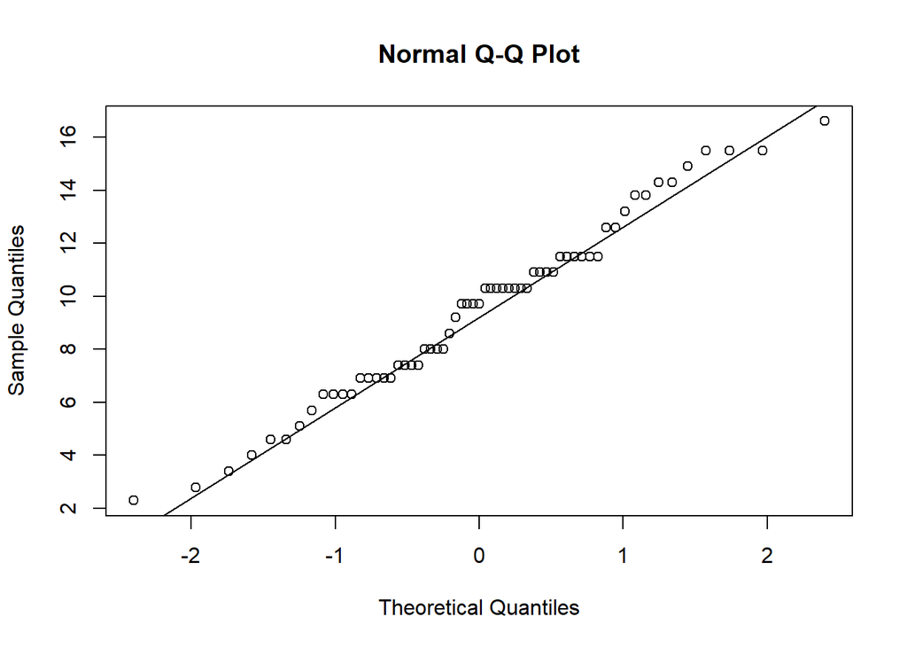

```r
qqnorm(wind)
qqline(wind)
```

The tail behaviour is largely the same as a normal distribution. It is not unreasonable to say the data is approximately normal.

To test the hypothesis that the mean wind speed is 10m/s, our null hypothesis $H_0$ is that the mean wind speed is equal to 10m/s. Our alternative hypothesis $H_1$ is then the inverse of it: the mean wind speed is **not** equal to 10m/s.

```r
xbar <- mean(wind); xbar
```

```
## [1] 9.47541
```

```r
n <- length(wind); n
```

```
## [1] 61
```

```r
s <- sd(wind); s
```

```
## [1] 3.388542
```

Using the normal approximation and the null hypothesis $H_0$ we have that $\bar{X} \sim N(10, 3.39^2 / 61)$ using our values for `s` and `n` above. The p-value can then be calculated. Since this is a two-sided test, we are looking for:

$$P(|\bar{X} - 10| > |9.48 - 10|) = P(\bar{X} < 9.48 \textrm{ or }
\bar{X} > 10.52)$$

Visualising what this is: under our null hypothesis, $\bar{X} \sim N(10, 3.39^2/61)$. Our observed $\bar{x} = 9.47541$. Where does this value lie on our distribution under the null hypothesis? The p-value represents the probability we would observe that value or something more extreme.

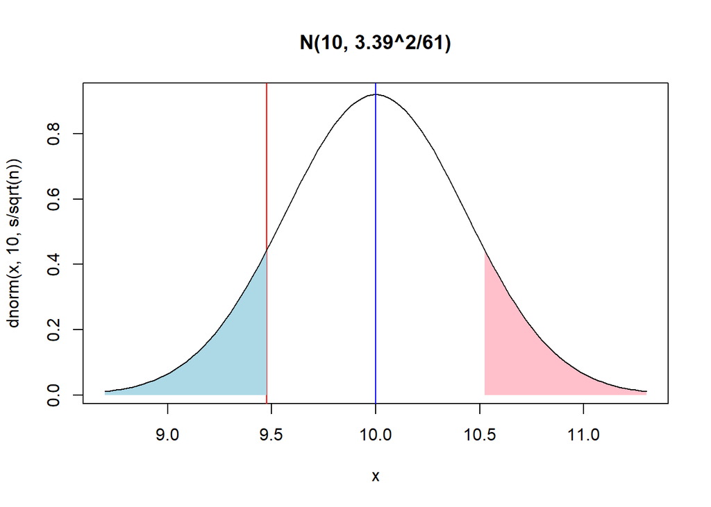

The red line represents our observed $\bar{x}$. The left light-blue area represents we would observe something *smaller* than $\bar{x} = 9.47541$, which has an area of approximately 11.33%.

```r
pnorm(xbar, 10, s/sqrt(n))
```

```
## [1] 0.1133069
```

Since this is a two-sided test, to get the p-value, we also need to find the right-tail probability in light-red. Instead of finding out the exact corresponding value, since the normal distribution is symmetric about its mean, we can just multiply this area by 2 to get the p-value.

```r
pnorm(xbar, 10, s/sqrt(n)) * 2
```

```
## [1] 0.2266138
```

To get the t-distribution, we must transform our `xbar` since the `pt` function doesn’t accept parameterisation of the mean and variance. Specifically, we are modelling that $\displaystyle{ \frac{\bar{X} - \mu}{s / \sqrt{n}} \sim t_{n-1} }$, substituting in the appropriate values for $\mu, n, s$.

```r
tstat <- (xbar - 10) / (s / sqrt(n))
pt(tstat, n-1) * 2
```

```
## [1] 0.2313569
```

And finally, using `t.test`:

```r
t.test(wind, mu=10)
```

```
##
##  One Sample t-test
##
## data:  wind
## t = -1.2091, df = 60, p-value = 0.2314
## alternative hypothesis: true mean is not equal to 10
## 95 percent confidence interval:
##   8.607564 10.343256
## sample estimates:
## mean of x
##   9.47541
```

To address the last question on comparing the p-values: the z-test and t-test have similar scores because $n = 61$, which makes the t-distribution quite close to a normal distribution. Plotted one atop the other, you can barely tell the difference.

```r
pnorm(xbar, 10, s/sqrt(n)) * 2
```

```
## [1] 0.2266138
```

```r
pt(tstat, n-1) * 2
```

```
## [1] 0.2313569
```

```r
t.test(wind, mu=10)$p.val
```

```
## [1] 0.2313569
```

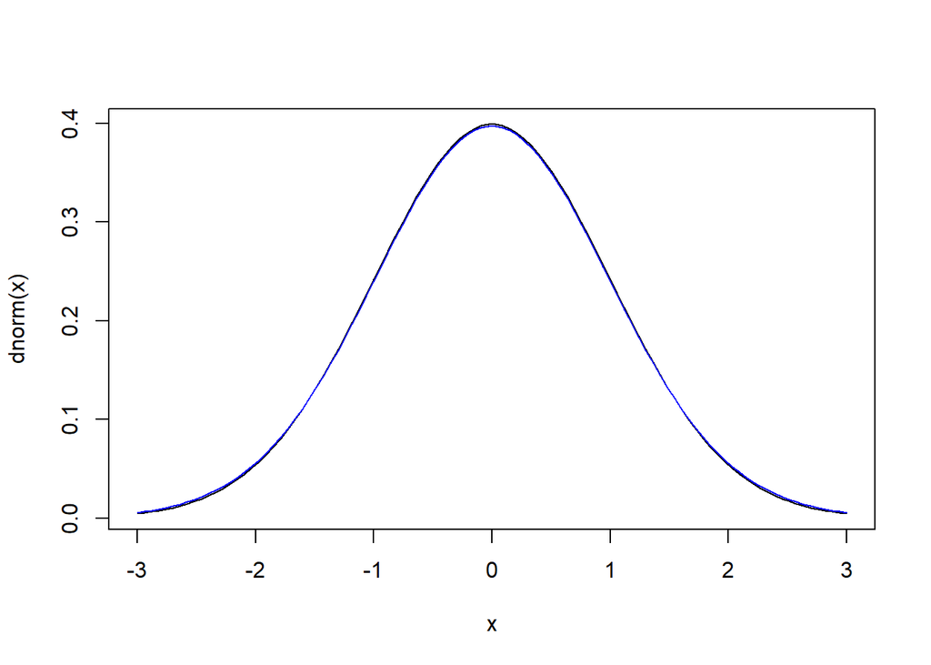

```r
x <- seq(-3, 3, length.out=100)
plot(x, dnorm(x), type='l')
lines(x, dt(x, n-1), type='l', col="blue")
```

# Exercise 6.3

We are testing $H_0 : \mu \leq 0.1$ against $H_1 : \mu > 0.1$. Since this is a one-sided test, we only need to get one tail - the right-sided tail. We observe the proportion to be $2700/25000 = 0.108$, so we are calculating $P(H_0 \textrm{ rejected} | H_0) = P(\bar{X} > 0.108 | \mu = 0.1)$.

```r
mu <- 0.1
n <- 25000
xbar <- 2700/25000
s <- sqrt(xbar * (1-xbar))
1 - pnorm(xbar, 0.1, s/sqrt(n))
```

```
## [1] 2.297188e-05
```

Visualising this is similar to above. The p-value is quite extreme. This is because of the large sample size, which lowers the variance of the distribution of $\bar{X}$. There is no left-sided tail here, because our alternative hypothesis is that $\mu > 0.1$.

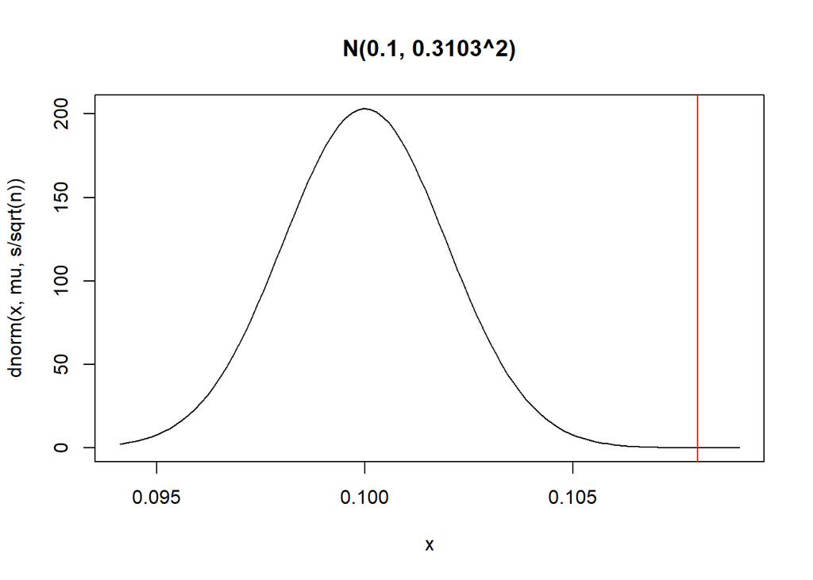

```r
x <- seq(mu -3*s/sqrt(n), mu +3*s/sqrt(n), length.out=100)
x <- seq(mu -3*s/sqrt(n), xbar+0.001, length.out=100)
plot(x, dnorm(x, mu, s/sqrt(n)), type="l", main = "N(0.1, 0.3103^2)")
abline(v=xbar, col="red")
```

```r
prop.test(2700,25000, p=0.1, alternative="greater")
```

```
##
##  1-sample proportions test with continuity correction
##
## data:  2700 out of 25000, null probability 0.1
## X-squared = 17.689, df = 1, p-value = 1.301e-05
## alternative hypothesis: true p is greater than 0.1
## 95 percent confidence interval:
##  0.1047937 1.0000000
## sample estimates:
##     p
## 0.108
```

# Exercise 6.4

Our two hypotheses are $H_0 : \mu = 0$ and $H_1 : \mu > 0$. Under the null hypothesis, $\bar{X} \sim N(0, 1/n)$.

The type-I error is exactly the p-values generated by our tests, as the type-I error describes exactly the probability of rejecting the null hypothesis when we shouldn’t have, i.e. $P(H_0 \textrm{ rejected} | H_0)$. We are given the decision rule to reject $H_0$ when $\bar{x} > 0.5$, so $P(H_0 \textrm{ rejected} | H_0) = P(\bar{X} > 0.5 | \mu = 0)$.

Think about the relation: the p-value gives the probability of observing that value or something more extreme. When we set a significance level, e.g. 95%, we also accept a 5% chance of rejecting the null hypothesis when we shouldn’t have.

```r
n <- c(10, 11, 20, 30)
p <- 1-pnorm(0.5, 0, 1/sqrt(n))
names(p) <- paste("n =", n)
p
```

```
##     n = 10     n = 11     n = 20     n = 30
## 0.05692315 0.04862721 0.01267366 0.00308495
```

The type-II error is when we fail to reject the null hypothesis when we should have, i.e. $P(H_0 \textrm{ not rejected} | H_1)$. Again, given the decision rule of rejecting when $\bar{x} > 0.5$, $P(H_0 \textrm{ not rejected} | H_1) = P(\bar{X} \leq 0.5 | H_1)$.

The power is 1 minus this type-II error, corresponding to the probability we reject the null hypothesis correctly: $1 - P(H_0 \textrm{ not rejected} | H_1) = P(H_0 \textrm{ rejected} | H_1)$.

Note an important detail: here, we consider the data **given** $H_1$! When we were calculating p-values, we always considered the data **given** $H_0$, because we want to see evidence *against* the null hypothesis.

We set different alternative hypotheses $H_1$, setting $\mu = 1.0, 1.1, 1.2, 1.3$. We fix $n = 11$, so $\bar{X} \sim N(\mu, 1/11)$. So, the quantity we want is $P(H_0 \textrm{ rejected} | H_1) = P(\bar{X} > 0.5 | \mu)$, changing the value of $\mu$ as needed.

```r
mu <- c(1.0, 1.1, 1.2, 1.3)
n = 11
power <- 1 - pnorm(0.5, mu, 1/sqrt(n))
names(power) <- paste("mu =", mu)
power
```

```
##    mu = 1  mu = 1.1  mu = 1.2  mu = 1.3
## 0.9513728 0.9767031 0.9898738 0.9960145
```